# DAtest - Multi-class variable

Jakob Russel

November 2017

# Intro

This is an example of using the DAtest package for a multi-class variable. The example uses the phyloseq package (https://joey711.github.io/phyloseq/), but a similar workflow can be used if your count-data is stored in a data.frame or matrix.

## Load packages

```r
library(phyloseq)
library(DAtest)
```

## Import

These files are downloaded from https://www.hmpdacc.org/hmp/HMQCP/

```r
otu <- import_qiime_otu_tax("v35_psn_otu.genus.fixed.txt")
map <- import_qiime_sample_data("v35_map_uniquebyPSN.txt")
```

### Create phyloseq object

```r
otu.tab <- otu_table(otu[[1]], taxa_are_rows = TRUE)
tax.tab <- tax_table(otu[[2]])
all_samples <- merge_phyloseq(otu.tab, tax.tab, map)
```

### Subset

This is just an arbitrary subset just for testing the package

```r
# Only Tongue, Saliva and Throat samples
TST <- subset_samples(all_samples, HMPbodysubsite %in% c("Tongue_dorsum","Saliva","Throat"))
# Only samples with at least 5000 reads
TST <- subset_samples(TST, sample_sums(TST) > 5000)
# Only samples from patients first visit
TST <- subset_samples(TST, visitno == 1)
# Only OTUs with at least 100 reads
TST <- preDA(TST, min.samples = 0, min.reads = 100, min.abundance = 0)
```

```
## 43251 features grouped as 'Others' in the output
```

## Run test

If you don’t have a phyloseq object your count data in a data.frame/matrix should be substituted for `TST` and a factor denoting the groups should be substituted for `"HMPbodysubsite"`.

```r
test <- testDA(TST, predictor = "HMPbodysubsite")
```

```
## Seed is set to 123
```

```
## predictor is assumed to be a categorical variable with 3 levels: Saliva, Throat, Tongue_dorsum
```

#### Details from the run:

First we ensure that the function has loaded the data correctly. For example that the predictor type is as expected, and the number of samples and features are as expected.

```r
test$details
```

```
##
## Features                            2133
## Samples                              231
## Predictor                    Multi-class
## Ordering   Saliva, Throat, Tongue_dorsum
## Paired                                No
## Covars
## RunTime                    22.43 Minutes
## Relative                            TRUE
## EffectSize                             4
## Spiked              Low:5, Mid:5, High:5
## RandomSeed                           123
## OutAll                              TRUE
```

### Check results

We can plot the results:

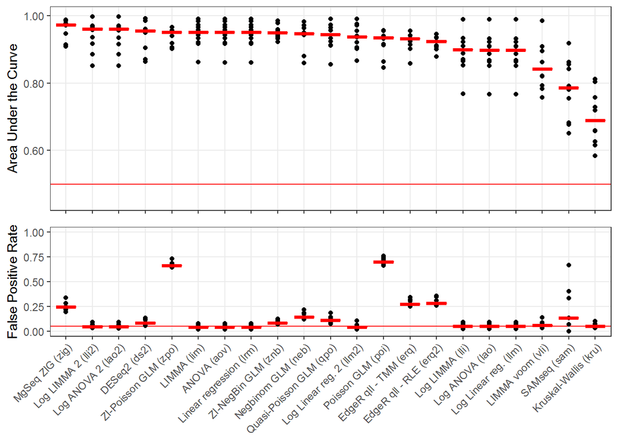

```r
plot(test)
```

Lets get a summary of the results, and check out the spike detect rate (proportion spiked features with adjusted p-value < 0.05)

```r
summary(test)
```

```
##                    Method   AUC   FPR Spike.detect.rate
##           MgSeq ZIG (zig) 0.974 0.243             0.900
##        Log ANOVA 2 (lao2) 0.960 0.047             0.433
##        Log LIMMA 2 (lli2) 0.960 0.046             0.433
##              DESeq2 (ds2) 0.955 0.082             0.533
##      ZI-Poisson GLM (zpo) 0.952 0.663             1.000
##               ANOVA (aov) 0.951 0.042             0.367
##               LIMMA (lim) 0.951 0.041             0.367
##   Linear regression (lrm) 0.951 0.042             0.367
##       ZI-NegBin GLM (znb) 0.949 0.083             0.633
##        Negbinom GLM (neb) 0.947 0.143             0.733
##   Quasi-Poisson GLM (qpo) 0.945 0.109             0.600
##  Log Linear reg. 2 (llm2) 0.938 0.041             0.267
##         Poisson GLM (poi) 0.934 0.700             1.000
##     EdgeR qll - TMM (erq) 0.932 0.270             0.933
##    EdgeR qll - RLE (erq2) 0.924 0.283             0.933
##           Log LIMMA (lli) 0.900 0.050             0.167
##           Log ANOVA (lao) 0.898 0.051             0.133
##     Log Linear reg. (llm) 0.898 0.051             0.133
##          LIMMA voom (vli) 0.842 0.059             0.133
##              SAMseq (sam) 0.786 0.133             0.133
##      Kruskal-Wallis (kru) 0.689 0.052             0.000
```

If your Spike.detect.rate is zero for the best method, you might want to run `testDA` again with a higher effectSize, but we would rarely expect a Spike.detect.rate above 0.500. Therefore, as long as the Spike.detect.rate is above zero for the best method we can continue.

Log Limma 2 and Log Anova 2 have the highest AUCs among those that control the false positive rate.

Lets check out the results from different methods

## Run Log Limma 2 (log transformation after relative abundance normalization)

Lets run Log Limma 2 with the original data to get the final results:

```r
results.lli2 <- DA.lli2(TST, predictor = "HMPbodysubsite")
```

results.lli2 contains the final results. Alternatively, run `DA.lli2` with `allResults=TRUE` and use `topTable` on the output.

## Run MetagenomeSeq ZIG

Lets run MG ZIG with the original data to get the final results:

```r
results.zig <- DA.zig(TST, predictor = "HMPbodysubsite")
```

```
## it= 0, nll=355.38, log10(eps+1)=Inf, stillActive=2133
## it= 1, nll=379.22, log10(eps+1)=0.03, stillActive=256
## it= 2, nll=379.23, log10(eps+1)=0.04, stillActive=162
## it= 3, nll=379.31, log10(eps+1)=0.06, stillActive=85
## it= 4, nll=379.45, log10(eps+1)=0.06, stillActive=48
## it= 5, nll=379.43, log10(eps+1)=0.02, stillActive=32
## it= 6, nll=379.39, log10(eps+1)=0.02, stillActive=20
## it= 7, nll=379.37, log10(eps+1)=0.02, stillActive=14
## it= 8, nll=379.35, log10(eps+1)=0.01, stillActive=12
## it= 9, nll=379.31, log10(eps+1)=0.03, stillActive=11
```

With `DA.zig` you have to use the `by` argument to specify which level of the `predictor` you want to compare against the intercept (first level of predictor).

## DESeq2

Lets run DESeq2 with the original data to get the final results:

```r
results.ds2 <- DA.ds2(TST, predictor = "HMPbodysubsite")
```

With `DA.ds2` the `coeff` argument specifies which level of the predictor the `log2FoldChange` is associated with. Alternatively, run `DA.ds2` with `allResults=TRUE` and use `results` on the output.

## EdgeR quasi-likelihood

Lets run EdgeR with the original data to get the final results:

```r
results.erq <- DA.erq(TST, predictor = "HMPbodysubsite")
```

## Run ANOVA

Lets run ANOVA with the original data and try to do Tukey post-hoc test:

```r
results.aov <- DA.aov(TST, predictor = "HMPbodysubsite", allResults = TRUE)
results.tukey <- DA.TukeyHSD(results.aov)
```

results.tukey contains the results of the post-hoc tests.

## Run Linear Regression (similar for other linear models and GLMs)

Lets run linear regression with the original data and try to do a post-hoc test:

```r
results.lrm.all <- DA.lrm(TST, predictor = "HMPbodysubsite", allResults = TRUE)
results.lsmeans <- DA.lsmeans(results.lrm.all)
```

results.lsmeans contains the results of the post-hoc tests.

Lets see the results of the most significant OTU:

```r
# Lowest p-value
results.lrm <- DA.lrm(TST, predictor = "HMPbodysubsite")
low.p.feat <- results.lrm[which.min(results.lrm$pval.adj),"Feature"]
results.lsmeans[rownames(results.lsmeans) == low.p.feat,c(1:3,7:9)]
```

```
##        estimate_Saliva - Throat estimate_Saliva - Tongue_dorsum
## Others               0.04010862                      0.07164246
##        estimate_Throat - Tongue_dorsum pval.adj_Saliva - Throat
## Others                      0.03153383             0.0007477958
##        pval.adj_Saliva - Tongue_dorsum pval.adj_Throat - Tongue_dorsum
## Others                    2.036571e-11                     0.008338416
```

All pairwise comparisons are significant. Lets plot it to see how it looks

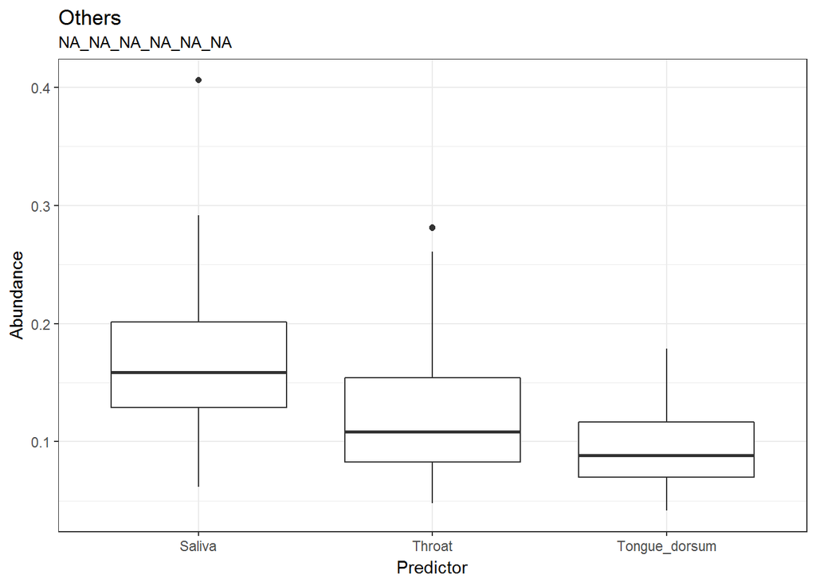

```r
# Plot it
featurePlot(TST, predictor = "HMPbodysubsite", feature = low.p.feat)
```

Intriguingly, it is all the low-abundant OTUs grouped as “Others” that are most significant. It appears that the Saliva samples contain more low abundant OTUs than the Throat and Tongue samples, and that the Throat samples contain more low abundant OTUs than the Tongue samples.

### Test if groups of features are overrepresented among the significant features

If the features belong to certains groups, we can test if features from certain groups are more likely to be significant than features from the other groups. For microbiome data we can use a taxonomy table, and if we have a phyloseq object we simply input the tax_table and specify here to use the 2. column (Phylum) to group by. `group.df` can be any data.frame as long as it has a grouping variable and the rownames match the “Feature” column in `results`.

```r
results.group <- groupSig(results = results.lli2, group.df = tax_table(TST), group.cols = 2)
head(results.group[order(results.group$pval.adj),])
```

```
##    GroupName          Group       OR         pval     pval.adj
## 1     Phylum Actinobacteria 2.321263 1.284079e-07 1.284079e-06
## 3     Phylum     Firmicutes 1.486651 5.062288e-06 2.531144e-05
## 6     Phylum Proteobacteria 1.634038 1.491901e-05 4.973004e-05
## 10    Phylum            TM7      Inf 8.742939e-02 2.185735e-01
## 8     Phylum            SR1      Inf 2.959176e-01 5.918352e-01
## 5     Phylum           GN02      Inf 5.440901e-01 8.511906e-01
```

Here we see that especially OTUs from the Actinobacteria phylum are overrepresented among the significant ones

### All tests

Lets try to run all tests and compare their results

```r
test.all <- allDA(TST, predictor = "HMPbodysubsite")
```

```
## predictor is assumed to be a categorical variable with 3 levels: Saliva, Throat, Tongue_dorsum
```

```
## Seed is set to 123
```

We can pull out results from specific methods. E.g. limma (lim):

```r
head(test.all$results$lim)
```

```
##              predictorThroat predictorTongue_dorsum      AveExpr        F
## Others         -4.010862e-02          -0.0716424571 0.1243036454 35.32148
## OTU_97.20       1.331853e-03           0.0081066171 0.0077078651 31.94128
## OTU_97.42321    2.847786e-05           0.0003963542 0.0002177945 31.45706
## OTU_97.10894   -1.968220e-05           0.0001676175 0.0001021912 29.89545
## OTU_97.98      -8.801501e-04          -0.0009382869 0.0002830799 28.98109
## OTU_97.24      -5.341751e-04          -0.0005487106 0.0001793728 28.42873
##                      pval     pval.adj      Feature      Method
## Others       4.256315e-14 9.078719e-11       Others LIMMA (lim)
## OTU_97.20    5.806904e-13 6.032999e-10    OTU_97.20 LIMMA (lim)
## OTU_97.42321 8.485230e-13 6.032999e-10 OTU_97.42321 LIMMA (lim)
## OTU_97.10894 2.908204e-12 1.550800e-09 OTU_97.10894 LIMMA (lim)
## OTU_97.98    6.019381e-12 2.567868e-09    OTU_97.98 LIMMA (lim)
## OTU_97.24    9.362194e-12 3.119262e-09    OTU_97.24 LIMMA (lim)
```

#### Euler (Venn) diagrams of three select methods

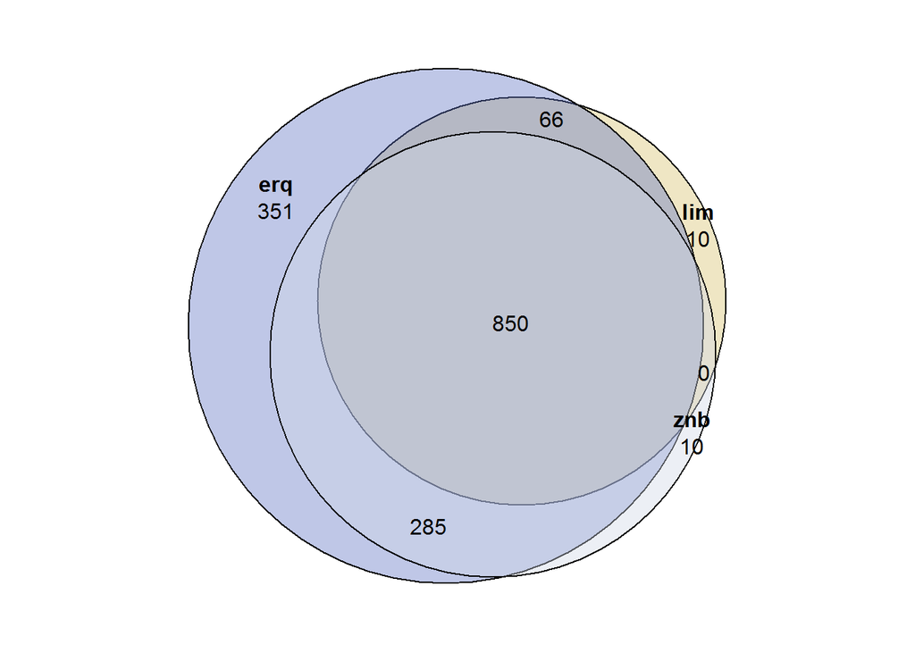

```r
vennDA(test.all, tests = c("lim","erq","znb"))
```